# Effects of taurine, cysteine and melatonin as antioxidant supplements to the freezing medium of Prrochilodus brevis sperm

Cândido Sobrinho, SA

2023-09-25

### 1 Loading required packages

In order to proceed, **the following packages must be installed**:

```r
base::library(tidyverse)
base::library(readxl)
base::library(ggpubr)
base::library(rstatix)
base::library(agricolae)
base::library(ggthemes)
base::library(FactoMineR)
base::library(rcompanion)
base::library(FSA)
base::library(factoextra)
base::library(agricolae)
```

### 2 Declaring user-made functions

Three custom functions were created for graphics and statistical analysis.

#### 2.1 Graphs (for discrete data)

With this function we generate boxplots for discrete data such relative frequencies (%).

```r
graphs_discrete <- function(treatment){

    data$experiment |>

    dplyr::filter(Treatment2 == treatment, Variable %in% c("Membrane integrity",
                  "Normal morphology", "Motility", "Rapid", "DNA integrity")) |>

    ggpubr::ggboxplot(x = "Concentration", y = "VALUE1", color = "Variable",
                      add = "jitter", #facet.by = "Variable",
                      xlab = paste0(treatment, "Concentration (mM)"), ylab = "Frequency (%)") +

    ggplot2::facet_wrap(facets = ~ Variable, scales = "free") +

    ggplot2::ylim(0,100) + ggthemes::scale_color_colorblind()
}
```

#### 2.2 Graphs (for continuous data)

This function generates boxplots for continuous data, in this study, VCL, VAP and VSL.

```r
graphs_continuous <- function(treatment){

    data$experiment |>

    dplyr::filter(Treatment2 == treatment, Variable %in% c("VCL", "VAP", "VSL")) |>

    ggpubr::ggboxplot(x = "Concentration", y = "VALUE1", color = "Variable",
                      add = "jitter", #facet.by = "Variable",
                      xlab = paste0(treatment, "Concentration (mM)"), ylab = "Frequency (%)") +

    ggplot2::facet_wrap(facets = ~ Variable, scales = "free") +

    ggthemes::scale_color_colorblind()
}
```

#### 2.3 Kruskal-Wallis + post-hoc Dunn Test (Bonferroni) + Compact Letter Display (CLD)

This function creates a list which contains:

- 1. Kruskal-Wallis test summary;
- 2. Dunn Test;
- 3. Compact Letter Display dataframe

The decision to employ the Bonferroni correction method is due its robust familywise error rate (FWER) control. Although it is acknowledged its conservative nature may result in missing discoveries, when true significance is not detected, it offers a substantial advantage in terms of reliability thus making this approach as a parsimonious choice, even if it entails a trade-off in false and true discovery rate.

```r
dunntest_bonferroni <- function(treatment, variable) {

  base::list() -> list_tobe_returned

  FSA::dunnTest(x = VALUE1 ~ Treatment,
                data = data$experiment |>
                       dplyr::filter(Treatment2 != "Control") |>
                       dplyr::filter(Treatment2 == treatment, Variable   == variable),
                method = "bonferroni") -> list_tobe_returned$dunn

  list_tobe_returned[["dunn"]][["dtres"]] -> list_tobe_returned$kruskal_wallis

  rcompanion::cldList(formula = P.adj ~ Comparison,
                      data = list_tobe_returned$dunn$res,
                      threshold = 0.05,
                      remove.zero = FALSE) -> list_tobe_returned$compact_letter_display

  return(list_tobe_returned)
}
```

### 3 Creating lists to store R outputs

The objects will be created and stored in these lists, in order to keep a tidy environment.

```r
for(n in base::c("data", "graphs", "stats")) { base::assign(n, base::list())}

base::list() -> stats$homogeneity
base::list() -> stats$normality
base::list() -> stats$kw_dunn

base::remove(n); base::gc()
```

```
##           used  (Mb) gc trigger  (Mb) max used  (Mb)
## Ncells 2620998 140.0    4469017 238.7  4469017 238.7
## Vcells 4401630  33.6   10146329  77.5  6979864  53.3
```

### 4 Loading dataset

The dataset will be loaded and stored in the object located at the path `data$experiment`.

```r
readxl::read_xlsx("./Data/Experiment.xlsx") |>

    base::as.data.frame() |>

    dplyr::mutate(Treatment2 = Treatment ) |>

    dplyr::mutate(Treatment = base::paste0(Treatment2, " ", "(", Concentration, "mM)")) -> data$experiment

base::gc()
```

```
##           used  (Mb) gc trigger  (Mb) max used  (Mb)
## Ncells 2647947 141.5    4469017 238.7  4469017 238.7
## Vcells 4464120  34.1   10146329  77.5  6979864  53.3
```

```r
readxl::read_xlsx("./Data/Fresh.xlsx") |>

    base::as.data.frame() |>

    tidyr::pivot_longer(cols = 2:9, names_to = "Variables", values_to = "Values") -> data$fresh
```

```r
readxl::read_xlsx("./Data/Concentration.xlsx") -> data$concentration
```

### 5 Data Analysis

#### 5.1 Shapiro-Wilk test for Normality.

```r
data$experiment |>
       dplyr::group_by(Treatment) |>
       rstatix::shapiro_test(VALUE1) -> stats[["normality"]]

base::gc()
```

```
##           used  (Mb) gc trigger  (Mb) max used  (Mb)
## Ncells 2693259 143.9    4469017 238.7  4469017 238.7
## Vcells 4565468  34.9   10146329  77.5  6979864  53.3
```

#### Results for this step:

```r
stats[["normality"]]
```

```
## # A tibble: 16 × 4
##    Treatment          variable statistic         p
##    <chr>              <chr>        <dbl>     <dbl>
##  1 Control (0mM)      VALUE1       0.920 0.00289
##  2 Cysteine (0.3mM)   VALUE1       0.916 0.000859
##  3 Cysteine (0mM)     VALUE1       0.913 0.000760
##  4 Cysteine (10mM)    VALUE1       0.874 0.0000345
##  5 Cysteine (1mM)     VALUE1       0.884 0.0000968
##  6 Cysteine (3.16mM)  VALUE1       0.885 0.0000760
##  7 Melatonin (0.6mM)  VALUE1       0.916 0.000918
##  8 Melatonin (0mM)    VALUE1       0.913 0.000760
##  9 Melatonin (1.12mM) VALUE1       0.904 0.000354
## 10 Melatonin (2mM)    VALUE1       0.931 0.00350
## 11 Melatonin (3.56mM) VALUE1       0.923 0.00239
## 12 Taurine (0.3mM)    VALUE1       0.903 0.000290
## 13 Taurine (0mM)      VALUE1       0.913 0.000760
## 14 Taurine (10mM)     VALUE1       0.905 0.000388
## 15 Taurine (1mM)      VALUE1       0.915 0.000755
## 16 Taurine (3.16mM)   VALUE1       0.901 0.000241
```

#### 5.2 Fligner-Kileen test for Homogeneity.

```r
for( i in unique(data$experiment$Variable) ) {

  stats::fligner.test(formula = VALUE1 ~ Treatment,
                      data = data$experiment |>
                             dplyr::filter(Variable == i)) -> stats[["homogeneity"]][[i]]}

base::remove(i); base::gc()
```

```
##           used  (Mb) gc trigger  (Mb) max used  (Mb)
## Ncells 2731370 145.9    4469017 238.7  4469017 238.7
## Vcells 4652780  35.5   10146329  77.5  6979864  53.3
```

#### Results for this step:

```r
stats[["homogeneity"]]
```

```
## $`Membrane integrity`
##
##  Fligner-Killeen test of homogeneity of variances
##
## data:  VALUE1 by Treatment
## Fligner-Killeen:med chi-squared = 28.8, df = 15, p-value = 0.01707
##
##
## $`Normal morphology`
##
##  Fligner-Killeen test of homogeneity of variances
##
## data:  VALUE1 by Treatment
## Fligner-Killeen:med chi-squared = 15.235, df = 15, p-value = 0.4347
##
##
## $Motility
##
##  Fligner-Killeen test of homogeneity of variances
##
## data:  VALUE1 by Treatment
## Fligner-Killeen:med chi-squared = 12.671, df = 15, p-value = 0.6277
##
##
## $Rapid
##
##  Fligner-Killeen test of homogeneity of variances
##
## data:  VALUE1 by Treatment
## Fligner-Killeen:med chi-squared = 16.007, df = 15, p-value = 0.3816
##
##
## $VCL
##
##  Fligner-Killeen test of homogeneity of variances
##
## data:  VALUE1 by Treatment
## Fligner-Killeen:med chi-squared = 17.789, df = 15, p-value = 0.2739
##
##
## $VSL
##
##  Fligner-Killeen test of homogeneity of variances
##
## data:  VALUE1 by Treatment
## Fligner-Killeen:med chi-squared = 19.773, df = 15, p-value = 0.1808
##
##
## $VAP
##
##  Fligner-Killeen test of homogeneity of variances
##
## data:  VALUE1 by Treatment
## Fligner-Killeen:med chi-squared = 24.449, df = 15, p-value = 0.05785
##
##
## $`DNA integrity`
##
##  Fligner-Killeen test of homogeneity of variances
##
## data:  VALUE1 by Treatment
## Fligner-Killeen:med chi-squared = 11.534, df = 14, p-value = 0.6437
```

### 6 Analysis of Variance (Kruskal-Wallis + posthoc Dunn)

Due to the observed tests results, we will proceed with a Dunn Test. The Kruskal-Wallis test is performed along with the function `FSA::dunnTest()`, which pairwise results for each factor level.

With the pairwise p-value for this global Dunn test, a pairwise comparison within groups using compact letter display (CLD) has been employed using `rcompaniion::cldList()` function, which produces a better readability for the overall reader and unveil possible grouped factor levels responses.

```r
for(i in c("Melatonin", "Taurine", "Cysteine")) {
  for(j in base::unique(data$experiment$Variable)){
    dunntest_bonferroni(i, j) -> stats[["kw_dunn"]][[i]][[j]]
  }
}

base::remove(i,j); base::gc()
```

```
##           used  (Mb) gc trigger  (Mb) max used  (Mb)
## Ncells 2752640 147.1    4469017 238.7  4469017 238.7
## Vcells 4699686  35.9   10146329  77.5  6979864  53.3
```

#### Results for this step:

```r
for(i in c("Melatonin", "Taurine", "Cysteine")) {
  for(j in base::unique(data$experiment$Variable)){
    print(stats[["kw_dunn"]][[i]][[j]])
  }
}
```

```
## Dunn (1964) Kruskal-Wallis multiple comparison
```

```
##   p-values adjusted with the Bonferroni method.
```

```
##                                 Comparison           Z    P.unadj     P.adj
## 1      Melatonin (0.6mM) - Melatonin (0mM)  1.67479112 0.09397522 0.9397522
## 2   Melatonin (0.6mM) - Melatonin (1.12mM) -0.48334585 0.62885019 1.0000000
## 3     Melatonin (0mM) - Melatonin (1.12mM) -2.13917480 0.03242151 0.3242151
## 4      Melatonin (0.6mM) - Melatonin (2mM)  0.25509920 0.79864648 1.0000000
## 5        Melatonin (0mM) - Melatonin (2mM) -1.42969974 0.15280322 1.0000000
## 6     Melatonin (1.12mM) - Melatonin (2mM)  0.73844505 0.46024405 1.0000000
## 7   Melatonin (0.6mM) - Melatonin (3.56mM) -0.02685255 0.97857734 1.0000000
## 8     Melatonin (0mM) - Melatonin (3.56mM) -1.70059022 0.08901996 0.8901996
## 9  Melatonin (1.12mM) - Melatonin (3.56mM)  0.45649331 0.64803528 1.0000000
## 10    Melatonin (2mM) - Melatonin (3.56mM) -0.28195175 0.77798051 1.0000000
##
## $kruskal_wallis
##  [1] "  Kruskal-Wallis rank sum test"
##  [2] ""
```

[output cut: 33 more lines]

```
## Dunn (1964) Kruskal-Wallis multiple comparison
##   p-values adjusted with the Bonferroni method.
```

```
##                                 Comparison          Z    P.unadj     P.adj
## 1      Melatonin (0.6mM) - Melatonin (0mM)  0.7177585 0.47290618 1.0000000
## 2   Melatonin (0.6mM) - Melatonin (1.12mM)  0.3393040 0.73438070 1.0000000
## 3     Melatonin (0mM) - Melatonin (1.12mM) -0.3784545 0.70509299 1.0000000
## 4      Melatonin (0.6mM) - Melatonin (2mM) -0.4828557 0.62919817 1.0000000
## 5        Melatonin (0mM) - Melatonin (2mM) -1.2006143 0.22990086 1.0000000
## 6     Melatonin (1.12mM) - Melatonin (2mM) -0.8221598 0.41098597 1.0000000
## 7   Melatonin (0.6mM) - Melatonin (3.56mM) -1.4877177 0.13682536 1.0000000
## 8     Melatonin (0mM) - Melatonin (3.56mM) -2.2054762 0.02742069 0.2742069
## 9  Melatonin (1.12mM) - Melatonin (3.56mM) -1.8270217 0.06769650 0.6769650
## 10    Melatonin (2mM) - Melatonin (3.56mM) -1.0048620 0.31496333 1.0000000
##
## $kruskal_wallis
##  [1] "  Kruskal-Wallis rank sum test"
##  [2] ""
```

[output cut: 33 more lines]

```
## Dunn (1964) Kruskal-Wallis multiple comparison
##   p-values adjusted with the Bonferroni method.
```

```
##                                 Comparison          Z    P.unadj     P.adj
## 1      Melatonin (0.6mM) - Melatonin (0mM)  1.4737377 0.14055223 1.0000000
## 2   Melatonin (0.6mM) - Melatonin (1.12mM)  0.5086351 0.61100799 1.0000000
## 3     Melatonin (0mM) - Melatonin (1.12mM) -0.9651026 0.33449344 1.0000000
## 4      Melatonin (0.6mM) - Melatonin (2mM) -0.8346833 0.40389605 1.0000000
## 5        Melatonin (0mM) - Melatonin (2mM) -2.3084210 0.02097573 0.2097573
## 6     Melatonin (1.12mM) - Melatonin (2mM) -1.3433184 0.17916888 1.0000000
## 7   Melatonin (0.6mM) - Melatonin (3.56mM) -1.0172703 0.30902487 1.0000000
## 8     Melatonin (0mM) - Melatonin (3.56mM) -2.4910080 0.01273813 0.1273813
## 9  Melatonin (1.12mM) - Melatonin (3.56mM) -1.5259054 0.12703342 1.0000000
## 10    Melatonin (2mM) - Melatonin (3.56mM) -0.1825870 0.85512211 1.0000000
##
## $kruskal_wallis
##  [1] "  Kruskal-Wallis rank sum test"
##  [2] ""
```

[output cut: 33 more lines]

```
## Dunn (1964) Kruskal-Wallis multiple comparison
##   p-values adjusted with the Bonferroni method.
```

```
##                                 Comparison           Z      P.unadj       P.adj
## 1      Melatonin (0.6mM) - Melatonin (0mM)  1.79013233 0.0734326405 0.734326405
## 2   Melatonin (0.6mM) - Melatonin (1.12mM) -0.03919998 0.9687309512 1.000000000
## 3     Melatonin (0mM) - Melatonin (1.12mM) -1.82933231 0.0673498415 0.673498415
## 4      Melatonin (0.6mM) - Melatonin (2mM) -1.41119921 0.1581858834 1.000000000
## 5        Melatonin (0mM) - Melatonin (2mM) -3.20133154 0.0013679404 0.013679404
## 6     Melatonin (1.12mM) - Melatonin (2mM) -1.37199923 0.1700636772 1.000000000
## 7   Melatonin (0.6mM) - Melatonin (3.56mM) -1.71173237 0.0869459997 0.869459997
## 8     Melatonin (0mM) - Melatonin (3.56mM) -3.50186470 0.0004620142 0.004620142
## 9  Melatonin (1.12mM) - Melatonin (3.56mM) -1.67253240 0.0944193852 0.944193852
## 10    Melatonin (2mM) - Melatonin (3.56mM) -0.30053316 0.7637705030 1.000000000
##
## $kruskal_wallis
##  [1] "  Kruskal-Wallis rank sum test"
##  [2] ""
```

[output cut: 33 more lines]

```
## Dunn (1964) Kruskal-Wallis multiple comparison
##   p-values adjusted with the Bonferroni method.
```

```
##                                 Comparison          Z      P.unadj       P.adj
## 1      Melatonin (0.6mM) - Melatonin (0mM)  2.2148271 0.0267719361 0.267719361
## 2   Melatonin (0.6mM) - Melatonin (1.12mM)  0.3490031 0.7270870166 1.000000000
## 3     Melatonin (0mM) - Melatonin (1.12mM) -1.8658240 0.0620659904 0.620659904
## 4      Melatonin (0.6mM) - Melatonin (2mM) -0.6845829 0.4936071517 1.000000000
## 5        Melatonin (0mM) - Melatonin (2mM) -2.8994100 0.0037386567 0.037386567
## 6     Melatonin (1.12mM) - Melatonin (2mM) -1.0335860 0.3013297618 1.000000000
## 7   Melatonin (0.6mM) - Melatonin (3.56mM) -1.7410394 0.0816766755 0.816766755
## 8     Melatonin (0mM) - Melatonin (3.56mM) -3.8689764 0.0001092932 0.001092932
## 9  Melatonin (1.12mM) - Melatonin (3.56mM) -2.0763507 0.0378615300 0.378615300
## 10    Melatonin (2mM) - Melatonin (3.56mM) -1.0833134 0.2786693423 1.000000000
##
## $kruskal_wallis
##  [1] "  Kruskal-Wallis rank sum test"
##  [2] ""
```

[output cut: 33 more lines]

```
## Dunn (1964) Kruskal-Wallis multiple comparison
##   p-values adjusted with the Bonferroni method.
```

```
##                                 Comparison          Z      P.unadj       P.adj
## 1      Melatonin (0.6mM) - Melatonin (0mM)  2.2690403 0.0232658780 0.232658780
## 2   Melatonin (0.6mM) - Melatonin (1.12mM)  0.5773298 0.5637167074 1.000000000
## 3     Melatonin (0mM) - Melatonin (1.12mM) -1.6917105 0.0907011881 0.907011881
## 4      Melatonin (0.6mM) - Melatonin (2mM) -0.2685255 0.7882948693 1.000000000
## 5        Melatonin (0mM) - Melatonin (2mM) -2.5375657 0.0111626404 0.111626404
## 6     Melatonin (1.12mM) - Melatonin (2mM) -0.8458552 0.3976335032 1.000000000
## 7   Melatonin (0.6mM) - Melatonin (3.56mM) -1.5006472 0.1334468247 1.000000000
## 8     Melatonin (0mM) - Melatonin (3.56mM) -3.6806706 0.0002326214 0.002326214
## 9  Melatonin (1.12mM) - Melatonin (3.56mM) -2.0553277 0.0398473592 0.398473592
## 10    Melatonin (2mM) - Melatonin (3.56mM) -1.2426563 0.2139945084 1.000000000
##
## $kruskal_wallis
##  [1] "  Kruskal-Wallis rank sum test"
##  [2] ""
```

[output cut: 33 more lines]

```
## Dunn (1964) Kruskal-Wallis multiple comparison
##   p-values adjusted with the Bonferroni method.
```

```
##                                 Comparison          Z      P.unadj       P.adj
## 1      Melatonin (0.6mM) - Melatonin (0mM)  2.5766625 0.0099759301 0.099759301
## 2   Melatonin (0.6mM) - Melatonin (1.12mM)  0.5770650 0.5638955198 1.000000000
## 3     Melatonin (0mM) - Melatonin (1.12mM) -1.9995975 0.0455437480 0.455437480
## 4      Melatonin (0.6mM) - Melatonin (2mM) -0.3086627 0.7575781235 1.000000000
## 5        Melatonin (0mM) - Melatonin (2mM) -2.8853252 0.0039100953 0.039100953
## 6     Melatonin (1.12mM) - Melatonin (2mM) -0.8857277 0.3757642586 1.000000000
## 7   Melatonin (0.6mM) - Melatonin (3.56mM) -1.4354910 0.1511472369 1.000000000
## 8     Melatonin (0mM) - Melatonin (3.56mM) -3.9110682 0.0000918888 0.000918888
## 9  Melatonin (1.12mM) - Melatonin (3.56mM) -1.9899171 0.0466000643 0.466000643
## 10    Melatonin (2mM) - Melatonin (3.56mM) -1.1389375 0.2547292424 1.000000000
##
## $kruskal_wallis
##  [1] "  Kruskal-Wallis rank sum test"
##  [2] ""
```

[output cut: 33 more lines]

```
## Dunn (1964) Kruskal-Wallis multiple comparison
##   p-values adjusted with the Bonferroni method.
```

```
##                                 Comparison           Z     P.unadj      P.adj
## 1      Melatonin (0.6mM) - Melatonin (0mM)  1.10240895 0.270283924 1.00000000
## 2   Melatonin (0.6mM) - Melatonin (1.12mM) -0.01592324 0.987295626 1.00000000
## 3     Melatonin (0mM) - Melatonin (1.12mM) -1.11893328 0.263168605 1.00000000
## 4      Melatonin (0.6mM) - Melatonin (2mM)  0.76431571 0.444679128 1.00000000
## 5        Melatonin (0mM) - Melatonin (2mM) -0.30924105 0.757138167 1.00000000
## 6     Melatonin (1.12mM) - Melatonin (2mM)  0.78023895 0.435250240 1.00000000
## 7   Melatonin (0.6mM) - Melatonin (3.56mM) -1.57640114 0.114933385 1.00000000
## 8     Melatonin (0mM) - Melatonin (3.56mM) -2.73831773 0.006175438 0.06175438
## 9  Melatonin (1.12mM) - Melatonin (3.56mM) -1.56047790 0.118646988 1.00000000
## 10    Melatonin (2mM) - Melatonin (3.56mM) -2.34071685 0.019246758 0.19246758
##
## $kruskal_wallis
##  [1] "  Kruskal-Wallis rank sum test"
##  [2] ""
```

[output cut: 33 more lines]

```
## Dunn (1964) Kruskal-Wallis multiple comparison
##   p-values adjusted with the Bonferroni method.
```

```
##                            Comparison          Z   P.unadj P.adj
## 1     Taurine (0.3mM) - Taurine (0mM)  0.6405795 0.5217959     1
## 2    Taurine (0.3mM) - Taurine (10mM) -0.1208180 0.9038352     1
## 3      Taurine (0mM) - Taurine (10mM) -0.7566577 0.4492550     1
## 4     Taurine (0.3mM) - Taurine (1mM)  0.4295751 0.6675048     1
## 5       Taurine (0mM) - Taurine (1mM) -0.2278571 0.8197573     1
## 6      Taurine (10mM) - Taurine (1mM)  0.5503930 0.5820498     1
## 7  Taurine (0.3mM) - Taurine (3.16mM) -0.6846353 0.4935741     1
## 8    Taurine (0mM) - Taurine (3.16mM) -1.2983558 0.1941651     1
## 9   Taurine (10mM) - Taurine (3.16mM) -0.5638173 0.5728785     1
## 10   Taurine (1mM) - Taurine (3.16mM) -1.1142103 0.2651890     1
##
## $kruskal_wallis
##  [1] "  Kruskal-Wallis rank sum test"
##  [2] ""
```

[output cut: 33 more lines]

```
## Dunn (1964) Kruskal-Wallis multiple comparison
##   p-values adjusted with the Bonferroni method.
```

```
##                            Comparison           Z    P.unadj     P.adj
## 1     Taurine (0.3mM) - Taurine (0mM) -0.73075745 0.46492732 1.0000000
## 2    Taurine (0.3mM) - Taurine (10mM) -1.50066262 0.13344285 1.0000000
## 3      Taurine (0mM) - Taurine (10mM) -0.76990517 0.44135615 1.0000000
## 4     Taurine (0.3mM) - Taurine (1mM) -1.52676110 0.12682043 1.0000000
## 5       Taurine (0mM) - Taurine (1mM) -0.79600365 0.42602991 1.0000000
## 6      Taurine (10mM) - Taurine (1mM) -0.02609848 0.97917879 1.0000000
## 7  Taurine (0.3mM) - Taurine (3.16mM) -1.65725350 0.09746823 0.9746823
## 8    Taurine (0mM) - Taurine (3.16mM) -0.92649605 0.35418825 1.0000000
## 9   Taurine (10mM) - Taurine (3.16mM) -0.15659088 0.87556729 1.0000000
## 10   Taurine (1mM) - Taurine (3.16mM) -0.13049240 0.89617687 1.0000000
##
## $kruskal_wallis
##  [1] "  Kruskal-Wallis rank sum test"
##  [2] ""
```

[output cut: 33 more lines]

```
## Dunn (1964) Kruskal-Wallis multiple comparison
##   p-values adjusted with the Bonferroni method.
```

```
##                            Comparison          Z   P.unadj P.adj
## 1     Taurine (0.3mM) - Taurine (0mM) -1.2259411 0.2202208     1
## 2    Taurine (0.3mM) - Taurine (10mM) -1.0824799 0.2790393     1
## 3      Taurine (0mM) - Taurine (10mM)  0.1434612 0.8859260     1
## 4     Taurine (0.3mM) - Taurine (1mM) -1.0824799 0.2790393     1
## 5       Taurine (0mM) - Taurine (1mM)  0.1434612 0.8859260     1
## 6      Taurine (10mM) - Taurine (1mM)  0.0000000 1.0000000     1
## 7  Taurine (0.3mM) - Taurine (3.16mM) -1.4998216 0.1336606     1
## 8    Taurine (0mM) - Taurine (3.16mM) -0.2738805 0.7841765     1
## 9   Taurine (10mM) - Taurine (3.16mM) -0.4173417 0.6764285     1
## 10   Taurine (1mM) - Taurine (3.16mM) -0.4173417 0.6764285     1
##
## $kruskal_wallis
##  [1] "  Kruskal-Wallis rank sum test"
##  [2] ""
```

[output cut: 33 more lines]

```
## Dunn (1964) Kruskal-Wallis multiple comparison
##   p-values adjusted with the Bonferroni method.
```

```
##                            Comparison           Z   P.unadj P.adj
## 1     Taurine (0.3mM) - Taurine (0mM)  0.65792824 0.5105842     1
## 2    Taurine (0.3mM) - Taurine (10mM) -0.27632986 0.7822947     1
## 3      Taurine (0mM) - Taurine (10mM) -0.93425810 0.3501708     1
## 4     Taurine (0.3mM) - Taurine (1mM)  0.96057523 0.3367658     1
## 5       Taurine (0mM) - Taurine (1mM)  0.30264699 0.7621589     1
## 6      Taurine (10mM) - Taurine (1mM)  1.23690509 0.2161223     1
## 7  Taurine (0.3mM) - Taurine (3.16mM)  0.56581829 0.5715173     1
## 8    Taurine (0mM) - Taurine (3.16mM) -0.09210995 0.9266107     1
## 9   Taurine (10mM) - Taurine (3.16mM)  0.84214815 0.3997050     1
## 10   Taurine (1mM) - Taurine (3.16mM) -0.39475694 0.6930223     1
##
## $kruskal_wallis
##  [1] "  Kruskal-Wallis rank sum test"
##  [2] ""
```

[output cut: 33 more lines]

```
## Dunn (1964) Kruskal-Wallis multiple comparison
##   p-values adjusted with the Bonferroni method.
```

```
##                            Comparison          Z   P.unadj P.adj
## 1     Taurine (0.3mM) - Taurine (0mM) -0.5478377 0.5838034     1
## 2    Taurine (0.3mM) - Taurine (10mM) -0.6521877 0.5142801     1
## 3      Taurine (0mM) - Taurine (10mM) -0.1043500 0.9168916     1
## 4     Taurine (0.3mM) - Taurine (1mM) -0.7695815 0.4415482     1
## 5       Taurine (0mM) - Taurine (1mM) -0.2217438 0.8245133     1
## 6      Taurine (10mM) - Taurine (1mM) -0.1173938 0.9065480     1
## 7  Taurine (0.3mM) - Taurine (3.16mM) -1.1608941 0.2456850     1
## 8    Taurine (0mM) - Taurine (3.16mM) -0.6130564 0.5398390     1
## 9   Taurine (10mM) - Taurine (3.16mM) -0.5087064 0.6109580     1
## 10   Taurine (1mM) - Taurine (3.16mM) -0.3913126 0.6955662     1
##
## $kruskal_wallis
##  [1] "  Kruskal-Wallis rank sum test"
##  [2] ""
```

[output cut: 33 more lines]

```
## Dunn (1964) Kruskal-Wallis multiple comparison
##   p-values adjusted with the Bonferroni method.
```

```
##                            Comparison          Z   P.unadj P.adj
## 1     Taurine (0.3mM) - Taurine (0mM) -0.4176343 0.6762145     1
## 2    Taurine (0.3mM) - Taurine (10mM) -0.6786557 0.4973561     1
## 3      Taurine (0mM) - Taurine (10mM) -0.2610214 0.7940760     1
## 4     Taurine (0.3mM) - Taurine (1mM) -0.8483196 0.3962600     1
## 5       Taurine (0mM) - Taurine (1mM) -0.4306853 0.6666972     1
## 6      Taurine (10mM) - Taurine (1mM) -0.1696639 0.8652745     1
## 7  Taurine (0.3mM) - Taurine (3.16mM) -1.5791795 0.1142949     1
## 8    Taurine (0mM) - Taurine (3.16mM) -1.1615453 0.2454202     1
## 9   Taurine (10mM) - Taurine (3.16mM) -0.9005239 0.3678415     1
## 10   Taurine (1mM) - Taurine (3.16mM) -0.7308599 0.4648647     1
##
## $kruskal_wallis
##  [1] "  Kruskal-Wallis rank sum test"
##  [2] ""
```

[output cut: 33 more lines]

```
## Dunn (1964) Kruskal-Wallis multiple comparison
##   p-values adjusted with the Bonferroni method.
```

```
##                            Comparison          Z   P.unadj P.adj
## 1     Taurine (0.3mM) - Taurine (0mM) -0.5347939 0.5927924     1
## 2    Taurine (0.3mM) - Taurine (10mM) -0.6782752 0.4975972     1
## 3      Taurine (0mM) - Taurine (10mM) -0.1434813 0.8859101     1
## 4     Taurine (0.3mM) - Taurine (1mM) -0.8087127 0.4186804     1
## 5       Taurine (0mM) - Taurine (1mM) -0.2739188 0.7841470     1
## 6      Taurine (10mM) - Taurine (1mM) -0.1304375 0.8962203     1
## 7  Taurine (0.3mM) - Taurine (3.16mM) -1.3695942 0.1708136     1
## 8    Taurine (0mM) - Taurine (3.16mM) -0.8348002 0.4038302     1
## 9   Taurine (10mM) - Taurine (3.16mM) -0.6913190 0.4893651     1
## 10   Taurine (1mM) - Taurine (3.16mM) -0.5608814 0.5748784     1
##
## $kruskal_wallis
##  [1] "  Kruskal-Wallis rank sum test"
##  [2] ""
```

[output cut: 33 more lines]

```
## Dunn (1964) Kruskal-Wallis multiple comparison
##   p-values adjusted with the Bonferroni method.
```

```
##                            Comparison          Z   P.unadj P.adj
## 1     Taurine (0.3mM) - Taurine (0mM) -0.3493771 0.7268062     1
## 2    Taurine (0.3mM) - Taurine (10mM) -1.1963648 0.2315542     1
## 3      Taurine (0mM) - Taurine (10mM) -0.8606941 0.3894065     1
## 4     Taurine (0.3mM) - Taurine (1mM)  0.2418765 0.8088759     1
## 5       Taurine (0mM) - Taurine (1mM)  0.5912536 0.5543505     1
## 6      Taurine (10mM) - Taurine (1mM)  1.4287522 0.1530755     1
## 7  Taurine (0.3mM) - Taurine (3.16mM) -0.9137556 0.3608453     1
## 8    Taurine (0mM) - Taurine (3.16mM) -0.5643785 0.5724966     1
## 9   Taurine (10mM) - Taurine (3.16mM)  0.3184568 0.7501384     1
## 10   Taurine (1mM) - Taurine (3.16mM) -1.1556321 0.2478317     1
##
## $kruskal_wallis
##  [1] "  Kruskal-Wallis rank sum test"
##  [2] ""
```

[output cut: 33 more lines]

```
## Dunn (1964) Kruskal-Wallis multiple comparison
##   p-values adjusted with the Bonferroni method.
```

```
##                              Comparison          Z    P.unadj     P.adj
## 1     Cysteine (0.3mM) - Cysteine (0mM)  0.2235579 0.82310129 1.0000000
## 2    Cysteine (0.3mM) - Cysteine (10mM) -1.7048760 0.08821755 0.8821755
## 3      Cysteine (0mM) - Cysteine (10mM) -1.8615498 0.06266657 0.6266657
## 4     Cysteine (0.3mM) - Cysteine (1mM) -1.2081799 0.22697809 1.0000000
## 5       Cysteine (0mM) - Cysteine (1mM) -1.3843396 0.16625449 1.0000000
## 6      Cysteine (10mM) - Cysteine (1mM)  0.4966962 0.61940333 1.0000000
## 7  Cysteine (0.3mM) - Cysteine (3.16mM) -0.8725743 0.38289513 1.0000000
## 8    Cysteine (0mM) - Cysteine (3.16mM) -1.0619003 0.28828097 1.0000000
## 9   Cysteine (10mM) - Cysteine (3.16mM)  0.8323017 0.40523868 1.0000000
## 10   Cysteine (1mM) - Cysteine (3.16mM)  0.3356055 0.73716836 1.0000000
##
## $kruskal_wallis
##  [1] "  Kruskal-Wallis rank sum test"
##  [2] ""
```

[output cut: 33 more lines]

```
## Dunn (1964) Kruskal-Wallis multiple comparison
##   p-values adjusted with the Bonferroni method.
```

```
##                              Comparison           Z   P.unadj P.adj
## 1     Cysteine (0.3mM) - Cysteine (0mM)  0.73080869 0.4648960     1
## 2    Cysteine (0.3mM) - Cysteine (10mM) -0.09135109 0.9272136     1
## 3      Cysteine (0mM) - Cysteine (10mM) -0.82215978 0.4109860     1
## 4     Cysteine (0.3mM) - Cysteine (1mM)  0.48285574 0.6291982     1
## 5       Cysteine (0mM) - Cysteine (1mM) -0.24795295 0.8041708     1
## 6      Cysteine (10mM) - Cysteine (1mM)  0.57420683 0.5658278     1
## 7  Cysteine (0.3mM) - Cysteine (3.16mM) -0.07830093 0.9375887     1
## 8    Cysteine (0mM) - Cysteine (3.16mM) -0.80910962 0.4184521     1
## 9   Cysteine (10mM) - Cysteine (3.16mM)  0.01305016 0.9895878     1
## 10   Cysteine (1mM) - Cysteine (3.16mM) -0.56115668 0.5746907     1
##
## $kruskal_wallis
##  [1] "  Kruskal-Wallis rank sum test"
##  [2] ""
```

[output cut: 33 more lines]

```
## Dunn (1964) Kruskal-Wallis multiple comparison
##   p-values adjusted with the Bonferroni method.
```

```
##                              Comparison          Z    P.unadj     P.adj
## 1     Cysteine (0.3mM) - Cysteine (0mM)  0.4303836 0.66691664 1.0000000
## 2    Cysteine (0.3mM) - Cysteine (10mM)  1.7084924 0.08754502 0.8754502
## 3      Cysteine (0mM) - Cysteine (10mM)  1.2781088 0.20121106 1.0000000
## 4     Cysteine (0.3mM) - Cysteine (1mM)  1.5389473 0.12381715 1.0000000
## 5       Cysteine (0mM) - Cysteine (1mM)  1.1085638 0.26761842 1.0000000
## 6      Cysteine (10mM) - Cysteine (1mM) -0.1695450 0.86536794 1.0000000
## 7  Cysteine (0.3mM) - Cysteine (3.16mM)  1.2781088 0.20121106 1.0000000
## 8    Cysteine (0mM) - Cysteine (3.16mM)  0.8477252 0.39659101 1.0000000
## 9   Cysteine (10mM) - Cysteine (3.16mM) -0.4303836 0.66691664 1.0000000
## 10   Cysteine (1mM) - Cysteine (3.16mM) -0.2608385 0.79421703 1.0000000
##
## $kruskal_wallis
##  [1] "  Kruskal-Wallis rank sum test"
##  [2] ""
```

[output cut: 33 more lines]

```
## Dunn (1964) Kruskal-Wallis multiple comparison
##   p-values adjusted with the Bonferroni method.
```

```
##                              Comparison          Z     P.unadj      P.adj
## 1     Cysteine (0.3mM) - Cysteine (0mM)  2.6249841 0.008665300 0.08665300
## 2    Cysteine (0.3mM) - Cysteine (10mM)  2.9531072 0.003145927 0.03145927
## 3      Cysteine (0mM) - Cysteine (10mM)  0.3281230 0.742818651 1.00000000
## 4     Cysteine (0.3mM) - Cysteine (1mM)  2.5593595 0.010486523 0.10486523
## 5       Cysteine (0mM) - Cysteine (1mM) -0.0656246 0.947676701 1.00000000
## 6      Cysteine (10mM) - Cysteine (1mM) -0.3937476 0.693767379 1.00000000
## 7  Cysteine (0.3mM) - Cysteine (3.16mM)  2.7562333 0.005847127 0.05847127
## 8    Cysteine (0mM) - Cysteine (3.16mM)  0.1312492 0.895578171 1.00000000
## 9   Cysteine (10mM) - Cysteine (3.16mM) -0.1968738 0.843926289 1.00000000
## 10   Cysteine (1mM) - Cysteine (3.16mM)  0.1968738 0.843926289 1.00000000
##
## $kruskal_wallis
##  [1] "  Kruskal-Wallis rank sum test"
##  [2] ""
```

[output cut: 33 more lines]

```
## Dunn (1964) Kruskal-Wallis multiple comparison
##   p-values adjusted with the Bonferroni method.
```

```
##                              Comparison          Z     P.unadj      P.adj
## 1     Cysteine (0.3mM) - Cysteine (0mM)  1.8389776 0.065918476 0.65918476
## 2    Cysteine (0.3mM) - Cysteine (10mM)  2.7383317 0.006175177 0.06175177
## 3      Cysteine (0mM) - Cysteine (10mM)  0.8993540 0.368464120 1.00000000
## 4     Cysteine (0.3mM) - Cysteine (1mM)  2.9791118 0.002890852 0.02890852
## 5       Cysteine (0mM) - Cysteine (1mM)  1.2122793 0.225405495 1.00000000
## 6      Cysteine (10mM) - Cysteine (1mM)  0.3482079 0.727684073 1.00000000
## 7  Cysteine (0.3mM) - Cysteine (3.16mM)  2.3490590 0.018820923 0.18820923
## 8    Cysteine (0mM) - Cysteine (3.16mM)  0.5100814 0.609994445 1.00000000
## 9   Cysteine (10mM) - Cysteine (3.16mM) -0.3892726 0.697074475 1.00000000
## 10   Cysteine (1mM) - Cysteine (3.16mM) -0.7222089 0.470166034 1.00000000
##
## $kruskal_wallis
##  [1] "  Kruskal-Wallis rank sum test"
##  [2] ""
```

[output cut: 33 more lines]

```
## Dunn (1964) Kruskal-Wallis multiple comparison
##   p-values adjusted with the Bonferroni method.
```

```
##                              Comparison          Z    P.unadj     P.adj
## 1     Cysteine (0.3mM) - Cysteine (0mM)  1.2082722 0.22694257 1.0000000
## 2    Cysteine (0.3mM) - Cysteine (10mM)  2.3091425 0.02093568 0.2093568
## 3      Cysteine (0mM) - Cysteine (10mM)  1.1008703 0.27095313 1.0000000
## 4     Cysteine (0.3mM) - Cysteine (1mM)  2.5539149 0.01065193 0.1065193
## 5       Cysteine (0mM) - Cysteine (1mM)  1.3930445 0.16360634 1.0000000
## 6      Cysteine (10mM) - Cysteine (1mM)  0.3353626 0.73735160 1.0000000
## 7  Cysteine (0.3mM) - Cysteine (3.16mM)  2.0943385 0.03622983 0.3622983
## 8    Cysteine (0mM) - Cysteine (3.16mM)  0.8860663 0.37558180 1.0000000
## 9   Cysteine (10mM) - Cysteine (3.16mM) -0.2148040 0.82992017 1.0000000
## 10   Cysteine (1mM) - Cysteine (3.16mM) -0.5417395 0.58799796 1.0000000
##
## $kruskal_wallis
##  [1] "  Kruskal-Wallis rank sum test"
##  [2] ""
```

[output cut: 33 more lines]

```
## Dunn (1964) Kruskal-Wallis multiple comparison
##   p-values adjusted with the Bonferroni method.
```

```
##                              Comparison          Z     P.unadj      P.adj
## 1     Cysteine (0.3mM) - Cysteine (0mM)  1.7180376 0.085789765 0.85789765
## 2    Cysteine (0.3mM) - Cysteine (10mM)  2.6710115 0.007562305 0.07562305
## 3      Cysteine (0mM) - Cysteine (10mM)  0.9529740 0.340603265 1.00000000
## 4     Cysteine (0.3mM) - Cysteine (1mM)  2.8327340 0.004615178 0.04615178
## 5       Cysteine (0mM) - Cysteine (1mM)  1.1820969 0.237167263 1.00000000
## 6      Cysteine (10mM) - Cysteine (1mM)  0.2665091 0.789847141 1.00000000
## 7  Cysteine (0.3mM) - Cysteine (3.16mM)  2.5367898 0.011187409 0.11187409
## 8    Cysteine (0mM) - Cysteine (3.16mM)  0.8187523 0.412927765 1.00000000
## 9   Cysteine (10mM) - Cysteine (3.16mM) -0.1342217 0.893227279 1.00000000
## 10   Cysteine (1mM) - Cysteine (3.16mM) -0.3954651 0.692499646 1.00000000
##
## $kruskal_wallis
##  [1] "  Kruskal-Wallis rank sum test"
##  [2] ""
```

[output cut: 33 more lines]

```
## Dunn (1964) Kruskal-Wallis multiple comparison
##   p-values adjusted with the Bonferroni method.
```

```
##                              Comparison           Z   P.unadj P.adj
## 1     Cysteine (0.3mM) - Cysteine (0mM)  0.13840582 0.8899197     1
## 2    Cysteine (0.3mM) - Cysteine (10mM) -0.66266378 0.5075459     1
## 3      Cysteine (0mM) - Cysteine (10mM) -0.79563979 0.4262414     1
## 4     Cysteine (0.3mM) - Cysteine (1mM) -0.71971026 0.4717034     1
## 5       Cysteine (0mM) - Cysteine (1mM) -0.85811608 0.3908284     1
## 6      Cysteine (10mM) - Cysteine (1mM) -0.02881147 0.9770150     1
## 7  Cysteine (0.3mM) - Cysteine (3.16mM) -1.39181557 0.1639783     1
## 8    Cysteine (0mM) - Cysteine (3.16mM) -1.52479158 0.1273111     1
## 9   Cysteine (10mM) - Cysteine (3.16mM) -0.70262824 0.4822875     1
## 10   Cysteine (1mM) - Cysteine (3.16mM) -0.70034032 0.4837148     1
##
## $kruskal_wallis
##  [1] "  Kruskal-Wallis rank sum test"
##  [2] ""
```

[output cut: 31 more lines]

### 7 Figures

#### 7.1 Boxplots for discrete data

```r
for(i in data$experiment$Treatment2) { graphs_discrete(treatment = i) -> graphs[[base::paste0(i,"_freq")]] }

base::remove(i); base::gc()
```

```
##           used  (Mb) gc trigger  (Mb) max used  (Mb)
## Ncells 2863964 153.0    4469017 238.7  4469017 238.7
## Vcells 4906894  37.5   10146329  77.5  6994922  53.4
```

#### Results for this step:

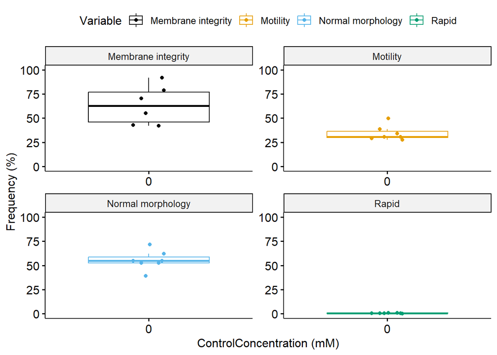

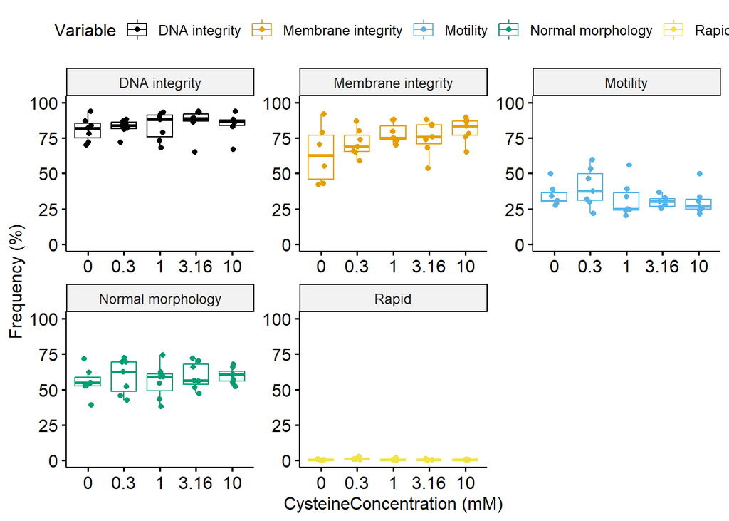

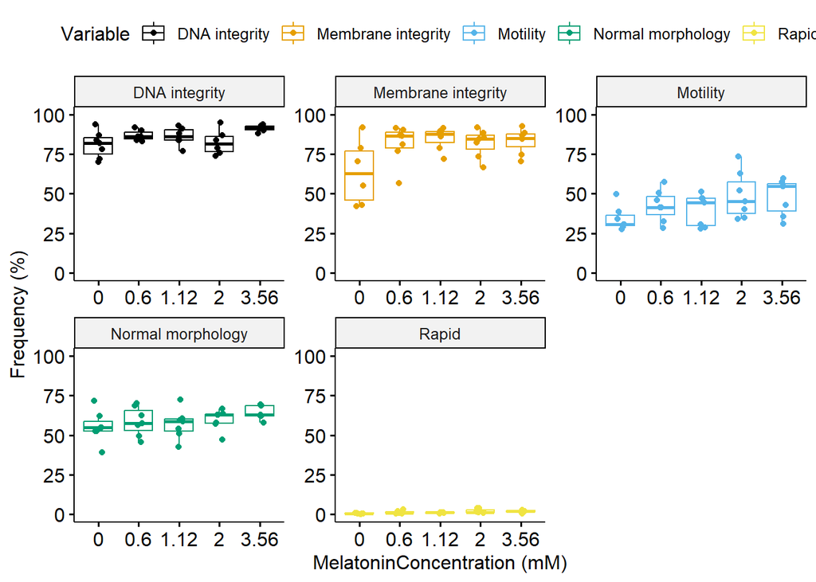

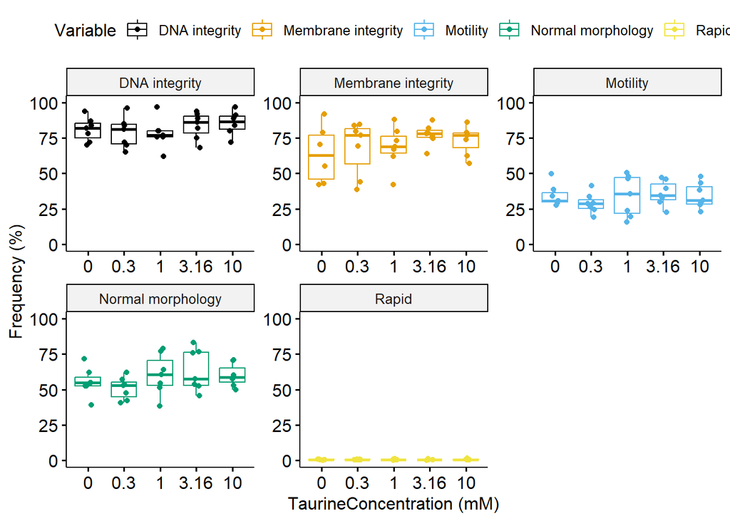

```r
for(i in base::ls(graphs, pattern = "_freq")) { print(graphs[[i]]) }
```

#### 7.2 Boxplots for continuous data

```r
for(i in data$experiment$Treatment2) { graphs_continuous(treatment = i) -> graphs[[base::paste0(i,"_vel")]] }

base::remove(i); base::gc()
```

```
##           used  (Mb) gc trigger  (Mb) max used  (Mb)
## Ncells 2951610 157.7    4469017 238.7  4469017 238.7
## Vcells 5092639  38.9   10146329  77.5  7066302  54.0
```

#### 7.3 Figure (Rapid, VAP, VCL, VSL)

```r
data$experiment |>

       dplyr::filter(Treatment %in% c("Control (0mM)", "Taurine (0.3mM)",
                                      "Taurine (1mM)", "Taurine (3.16mM)",
                                      "Taurine (10mM)", "Cysteine (0.3mM)",
                                      "Cysteine (1mM)", "Cysteine (3.16mM)",
                                      "Cysteine (10mM)", "Melatonin (0.6mM)",
                                      "Melatonin (1.12mM)",
                                      "Melatonin (2mM)", "Melatonin (3.56mM)")) |>

       dplyr::filter(Variable %in% c("Rapid", "VAP", "VCL", "VSL")) |>

       ggpubr::ggboxplot(x = "Treatment", y = "VALUE1",
                         add = "jitter", color = "Treatment",
                         ylab = "") +

       ggpubr::rotate_x_text() +

       ggplot2::theme(legend.position = "none") -> graphs$rapid_vel

       ggpubr::facet(graphs$rapid_vel, facet.by = "Variable", ncol = 1, scales = "free_y") -> graphs$rapid_vel
```

#### Results for these steps:

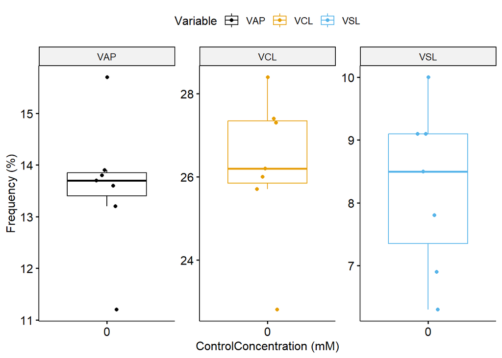

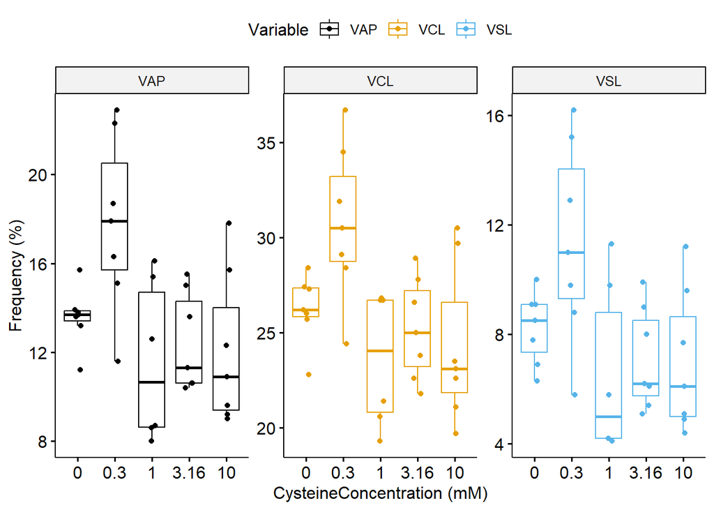

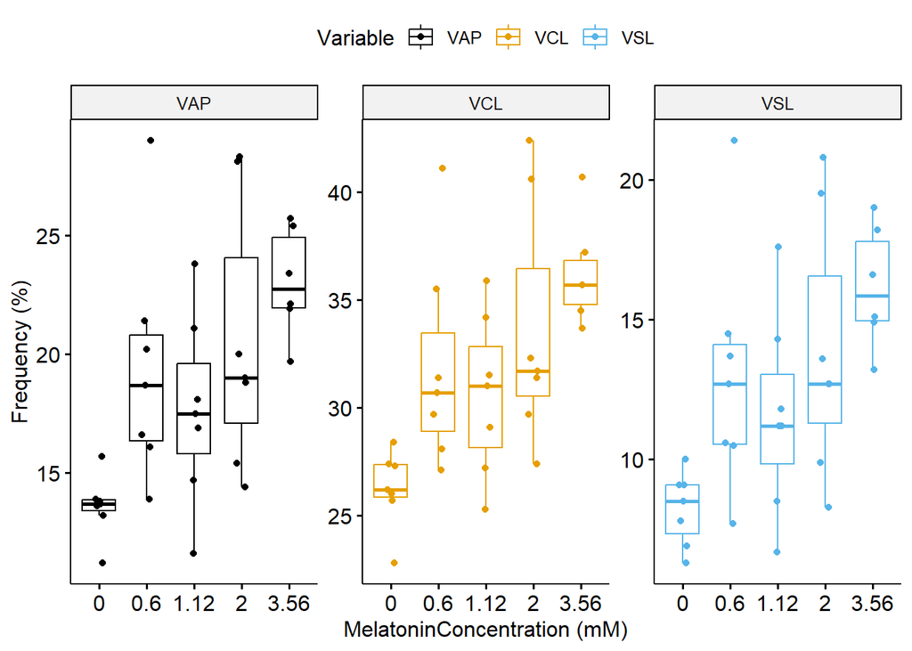

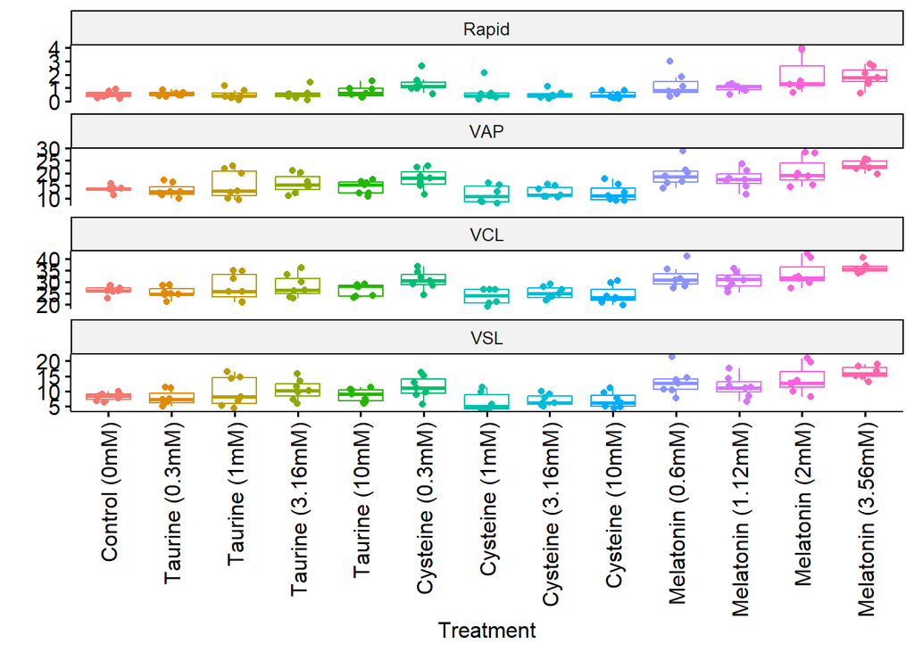

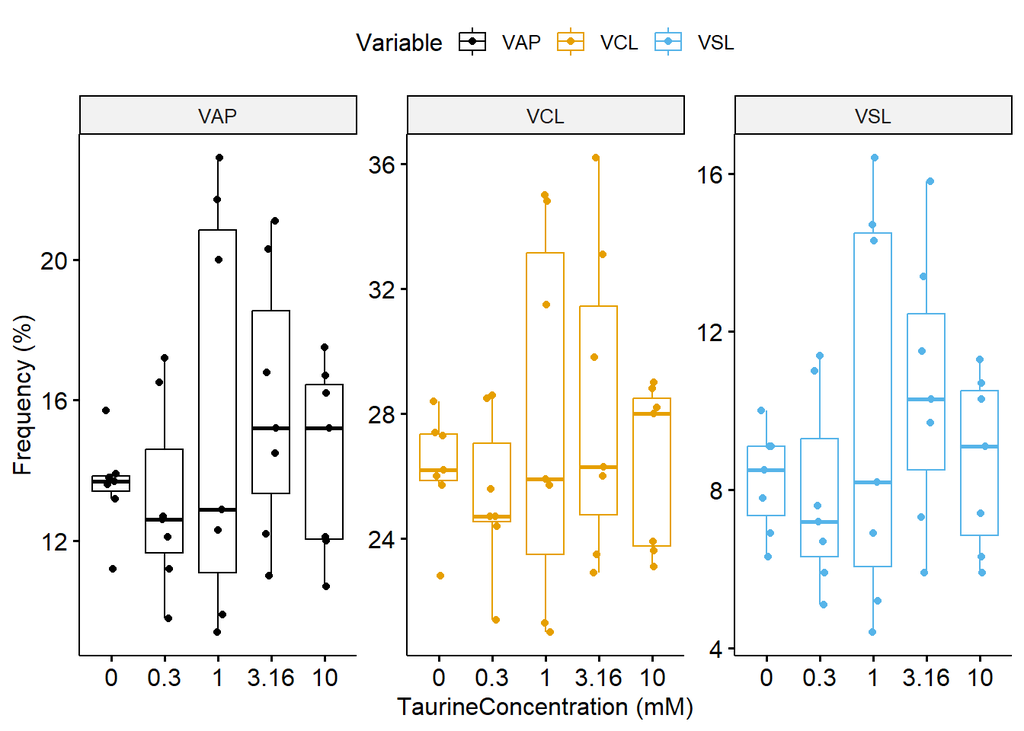

```r
for(i in base::ls(graphs, pattern = "_vel")) { print(graphs[[i]]) }
```

## 8 Additional tables under request - Descriptive statistics

#### 8.1 Fresh sperm table

```r
data$fresh |>

    dplyr::select(-Pool) |>

    dplyr::group_by(Variables) |>

    rstatix::get_summary_stats(Values) #|> utils::write.csv(file = "./table_fresh.csv")
```

```
## # A tibble: 8 × 14
##   Variables      variable     n   min   max median    q1    q3   iqr   mad  mean
##   <chr>          <fct>    <dbl> <dbl> <dbl>  <dbl> <dbl> <dbl> <dbl> <dbl> <dbl>
## 1 DNA integrity… Values       6  73    97     85    80    90   10    7.41   85
## 2 Membrane inte… Values       7  95    99     96    95.2  98    2.75 1.48   96.6
## 3 Motility       Values       7  95.1  99.1   98.9  97    99.0  2.05 0.297  97.9
## 4 Normal morpho… Values       6  77    95     91.8  85.1  92.4  7.25 2.96   88.5
## 5 Rapid          Values       7  16.6  67.5   57.2  43.0  61.4 18.4  7.12   50
## 6 VAP            Values       7  47.8  73.8   64.4  60.8  66.4  5.65 5.93   62.9
## 7 VCL            Values       7  68.6 111.   106.   90.3 109.  18.3  6.97   97.6
## 8 VSL            Values       7  32.7  48.7   44    37.7  46.3  8.6  6.23   41.9
## # ℹ 3 more variables: sd <dbl>, se <dbl>, ci <dbl>
```

#### 8.2 Table containing per treatment results

```r
data$experiment |>

    dplyr::select(Treatment, Variable, VALUE1) |>

    dplyr::group_by(Treatment, Variable) |>

    rstatix::get_summary_stats() |>

    dplyr::select(-c("variable", "n", "mad")) |>

    dplyr::rename(c("Minimum" = "min",
                  "Maximum" = "max",
                  "Mean" = "mean",
                  "Median" = "median",
                  "Q1" = "q1",
                  "Q3" = "q3",
                  "IQR" = "iqr",
                  "CI (95%)" = "ci")) #|> utils::write.csv(file = "./table_experiment.csv", row.names = FALSE)
```

```
## # A tibble: 127 × 12
##    Treatment     Variable Minimum Maximum Median    Q1    Q3   IQR   Mean     sd
##    <chr>         <chr>      <dbl>   <dbl>  <dbl> <dbl> <dbl> <dbl>  <dbl>  <dbl>
##  1 Control (0mM) Membran…    42      92     62.8 46    76.9  30.9  63.6   20.3
##  2 Control (0mM) Motility    27.7    49.9   30.7 29.8  36.3   6.45 34.4    7.73
##  3 Control (0mM) Normal …    39      71.5   55   52.5  58.5   6    55.4    9.91
##  4 Control (0mM) Rapid        0.2     0.9    0.5  0.35  0.65  0.3   0.514  0.254
##  5 Control (0mM) VAP         11.2    15.7   13.7 13.4  13.8   0.45 13.6    1.32
##  6 Control (0mM) VCL         22.8    28.4   26.2 25.8  27.4   1.5  26.3    1.79
##  7 Control (0mM) VSL          6.3    10      8.5  7.35  9.1   1.75  8.24   1.32
##  8 Cysteine (0.… DNA int…    72      88     84   81.5  86     4.5  82.7    5.34
##  9 Cysteine (0.… Membran…    59      87     69   65.5  77    11.5  71.4    9.61
## 10 Cysteine (0.… Motility    22      59.8   37.6 31.0  49.8  18.8  40.1   13.6
## # ℹ 117 more rows
## # ℹ 2 more variables: se <dbl>, `CI (95%)` <dbl>
```

#### 8.3 Table containing data from mean sperm concentration

```r
data$concentration |>

    dplyr::group_by(Pool) |>

    dplyr::mutate(Count = Count * 0.2 * 1E9) |>

    dplyr::summarise(`Sperm concentration (cells/mL)` = base::round(base::mean(Count),2),
                     `Standard Deviation` = base::round(stats::sd(Count),2),
                     Minimum = min(Count),
                     Maximum = max(Count)) #|> utils::write.csv(file = "./table_concentration.csv", row.names = FALSE)
```

```
## # A tibble: 7 × 5
##   Pool  `Sperm concentration (cells/mL)` `Standard Deviation`    Minimum Maximum
##   <chr>                            <dbl>                <dbl>      <dbl>   <dbl>
## 1 P1                         1033333333.           642910051.    3   e 8 1.5 e 9
## 2 P2                        13866666667.           611010093.    1.32e10 1.44e10
## 3 P3                        20300000000           2771281292.    1.87e10 2.35e10
## 4 P4                        18800000000           3764306045.    1.45e10 2.15e10
## 5 P5                        17412000000            961812872.    1.64e10 1.83e10
## 6 P6                        23100000000            692820323.    2.27e10 2.39e10
## 7 P7                        15400000000           2598076211.    1.39e10 1.84e10
```

## 9 PCA (and ANOVA from PCA results)

#### 9.1 Organizing dataset for a PCA (wider rather than longer)

```r
data$experiment |>

  dplyr::filter(Variable %in% c("VAP", "VSL", "VCL"), !Treatment %in% c("Melatonin (0mM)", "Taurine (0mM)", "Cysteine (0mM)")) |>

  dplyr::select(-c(VALUE2, VALUE3, Treatment2, Concentration)) |>

  dplyr::group_by(Treatment, Variable) |> dplyr::mutate(Treatments = paste0(Treatment, dplyr::row_number())) |>

  tidyr::pivot_wider(names_from = "Variable", values_from = "VALUE1") -> data$data4pca
```

#### 9.2 Building the PCA model

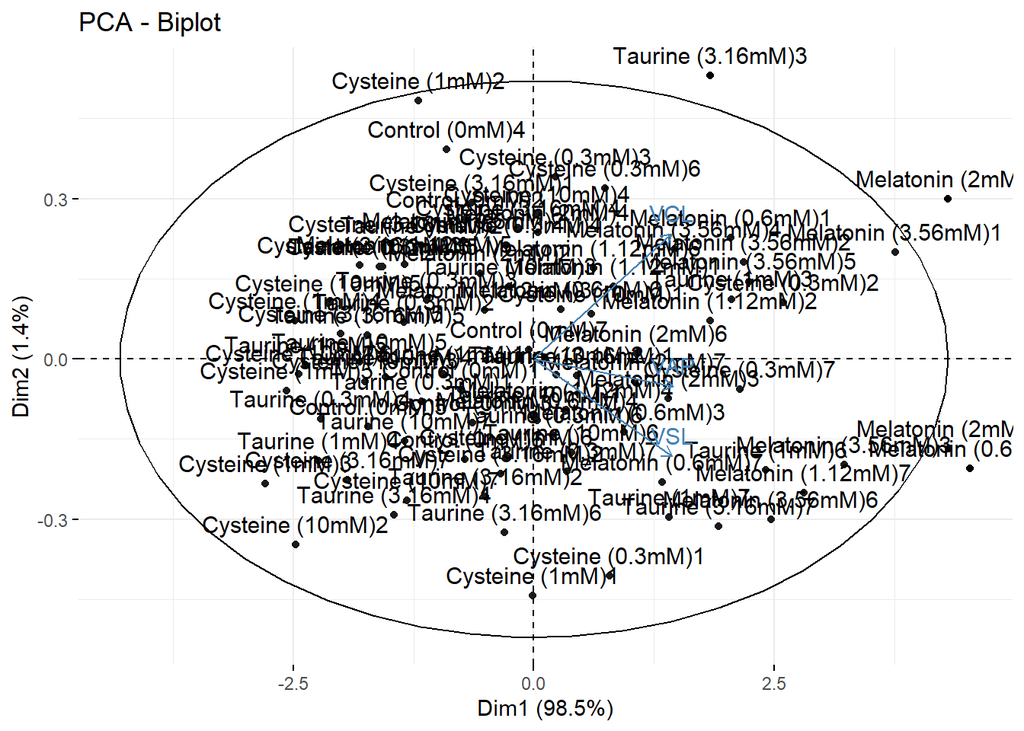

```r
FactoMineR::PCA(X = data$data4pca[3:5], ncp = 2, scale = TRUE, graph = FALSE) -> stats$PCA

data$data4pca$Treatments -> base::row.names(stats$PCA$ind$coord)

factoextra::fviz_pca_biplot(stats$PCA, addEllipses = TRUE)
```

#### 9.3 Obtaining a dataframe containing individual coordinates and their respective groups

```r
base::cbind.data.frame(coord = stats$PCA$ind$coord[,1], group = data$data4pca$Treatment) -> data$pcacoords_names
data$pcacoords_names
```

```
##                            coord              group
## Control (0mM)1      -0.753581478      Control (0mM)
## Control (0mM)2      -0.720134214      Control (0mM)
## Control (0mM)3      -0.635712038      Control (0mM)
## Control (0mM)4      -0.904671814      Control (0mM)
## Control (0mM)5      -1.725995889      Control (0mM)
## Control (0mM)6      -0.715006887      Control (0mM)
## Control (0mM)7      -0.051188279      Control (0mM)
## Taurine (0.3mM)1    -1.166682598    Taurine (0.3mM)
## Taurine (0.3mM)2    -1.352098176    Taurine (0.3mM)
## Taurine (0.3mM)3    -1.110875112    Taurine (0.3mM)
## Taurine (0.3mM)4    -2.215964174    Taurine (0.3mM)
## Taurine (0.3mM)5    -1.604604475    Taurine (0.3mM)
## Taurine (0.3mM)6     0.195129258    Taurine (0.3mM)
## Taurine (0.3mM)7     0.345731323    Taurine (0.3mM)
## Taurine (1mM)1      -0.936287354      Taurine (1mM)
## Taurine (1mM)2      -1.167344265      Taurine (1mM)
## Taurine (1mM)3       2.053314471      Taurine (1mM)
## Taurine (1mM)4      -2.234357064      Taurine (1mM)
## Taurine (1mM)5      -2.372581604      Taurine (1mM)
## Taurine (1mM)6       2.411941500      Taurine (1mM)
## Taurine (1mM)7       1.406545300      Taurine (1mM)
## Taurine (3.16mM)1    0.444795370   Taurine (3.16mM)
## Taurine (3.16mM)2   -0.502375720   Taurine (3.16mM)
## Taurine (3.16mM)3    1.837387701   Taurine (3.16mM)
## Taurine (3.16mM)4   -1.455768427   Taurine (3.16mM)
## Taurine (3.16mM)5   -1.728207263   Taurine (3.16mM)
## Taurine (3.16mM)6   -0.301699516   Taurine (3.16mM)
## Taurine (3.16mM)7    1.924682918   Taurine (3.16mM)
## Taurine (10mM)1      0.006158852     Taurine (10mM)
## Taurine (10mM)2      0.232543853     Taurine (10mM)
## Taurine (10mM)3     -0.258757826     Taurine (10mM)
## Taurine (10mM)4     -1.541740308     Taurine (10mM)
## Taurine (10mM)5     -1.808380090     Taurine (10mM)
## Taurine (10mM)6      0.389790096     Taurine (10mM)
## Taurine (10mM)7     -1.342993459     Taurine (10mM)
## Cysteine (0.3mM)1    0.789841963   Cysteine (0.3mM)
## Cysteine (0.3mM)2    2.594484037   Cysteine (0.3mM)
## Cysteine (0.3mM)3    0.225238006   Cysteine (0.3mM)
## Cysteine (0.3mM)4   -0.290439074   Cysteine (0.3mM)
```

[output cut: 35 more lines]

```
## Melatonin (1.12mM)6  0.619523672 Melatonin (1.12mM)
## Melatonin (1.12mM)7  2.808904015 Melatonin (1.12mM)
## Melatonin (2mM)1     4.308213035    Melatonin (2mM)
## Melatonin (2mM)2    -0.554694086    Melatonin (2mM)
## Melatonin (2mM)3     1.397440583    Melatonin (2mM)
## Melatonin (2mM)4     0.042987547    Melatonin (2mM)
## Melatonin (2mM)5     4.314218340    Melatonin (2mM)
## Melatonin (2mM)6     1.061878356    Melatonin (2mM)
## Melatonin (2mM)7     1.052557328    Melatonin (2mM)
## Melatonin (3.56mM)1  3.763184760 Melatonin (3.56mM)
## Melatonin (3.56mM)2  2.182683459 Melatonin (3.56mM)
## Melatonin (3.56mM)3  3.227944732 Melatonin (3.56mM)
## Melatonin (3.56mM)4  1.460813139 Melatonin (3.56mM)
## Melatonin (3.56mM)5  2.234513554 Melatonin (3.56mM)
## Melatonin (3.56mM)6  2.466405531 Melatonin (3.56mM)
```

##### 9.4 Running an ANOVA model + post-hoc Tukey

```r
stats::aov(data = data$pcacoords_names, formula = coord ~ group) -> stats$aov

#base::sink(file = "aov_results.txt")
base::summary(stats$aov)
```

```
##             Df Sum Sq Mean Sq F value   Pr(>F)
## group       12  126.2  10.515   5.846 4.58e-07 ***
## Residuals   76  136.7   1.799
## ---
## Signif. codes:  0 '***' 0.001 '**' 0.01 '*' 0.05 '.' 0.1 ' ' 1
```

```r
#base::sink()
```

#### 9.5 Performing an Tukey test

```r
stats$aov |> agricolae::HSD.test(trt = "group", group = TRUE) -> stats$tukey_hsd

stats$tukey_hsd$means #|> utils::write.csv(file = "tukey_means.csv")
```

```
##                          coord       std r        Min         Max         Q25
## Control (0mM)      -0.78661294 0.4950819 7 -1.7259959 -0.05118828 -0.82912665
## Cysteine (0.3mM)    0.66099374 1.4155514 7 -1.5707447  2.59448404 -0.03260053
## Cysteine (10mM)    -1.35635914 1.2226746 7 -2.4760027  0.60000364 -2.28871294
## Cysteine (1mM)     -1.55816442 1.2279919 6 -2.7894109 -0.01019606 -2.55202768
## Cysteine (3.16mM)  -1.20000989 0.7926752 7 -2.0113106 -0.15931413 -1.87450613
## Melatonin (0.6mM)   1.20609179 1.7256233 7 -0.7314604  4.53704851  0.15868437
## Melatonin (1.12mM)  0.65354459 1.3865826 7 -1.3454111  2.80890401 -0.08786590
## Melatonin (2mM)     1.66037159 1.9310265 7 -0.5546941  4.31421834  0.54777244
## Melatonin (3.56mM)  2.55592420 0.8196322 6  1.4608131  3.76318476  2.19564098
## Taurine (0.3mM)    -0.98705199 0.9350863 7 -2.2159642  0.34573132 -1.47835133
## Taurine (10mM)     -0.61762555 0.9177518 7 -1.8083801  0.38979010 -1.44236688
## Taurine (1mM)      -0.11982415 2.0319223 7 -2.3725816  2.41194150 -1.70085066
## Taurine (3.16mM)    0.03125929 1.4560659 7 -1.7282073  1.92468292 -0.97907207
##                           Q50        Q75
## Control (0mM)      -0.7201342 -0.6753595
## Cysteine (0.3mM)    0.7391162  1.4646509
## Cysteine (10mM)    -1.7565500 -0.6422695
## Cysteine (1mM)     -1.8417470 -0.5182599
## Cysteine (3.16mM)  -1.4843074 -0.4980625
## Melatonin (0.6mM)   0.9391535  1.6902660
## Melatonin (1.12mM)  0.6195237  1.3337637
## Melatonin (2mM)     1.0618784  2.8528268
## Melatonin (3.56mM)  2.3504595  3.0375599
## Taurine (0.3mM)    -1.1666826 -0.4578729
## Taurine (10mM)     -0.2587578  0.1193514
## Taurine (1mM)      -0.9362874  1.7299299
## Taurine (3.16mM)   -0.3016995  1.1410915
```

```r
stats$tukey_hsd$groups #|> utils::write.csv(file = "tukey_CLD.csv")
```

```
##                          coord groups
## Melatonin (3.56mM)  2.55592420      a
## Melatonin (2mM)     1.66037159     ab
## Melatonin (0.6mM)   1.20609179    abc
## Cysteine (0.3mM)    0.66099374   abcd
## Melatonin (1.12mM)  0.65354459   abcd
## Taurine (3.16mM)    0.03125929   abcd
## Taurine (1mM)      -0.11982415    bcd
## Taurine (10mM)     -0.61762555    bcd
## Control (0mM)      -0.78661294    bcd
## Taurine (0.3mM)    -0.98705199     cd
## Cysteine (3.16mM)  -1.20000989     cd
## Cysteine (10mM)    -1.35635914      d
## Cysteine (1mM)     -1.55816442      d
```